# Project: Investigate a Dataset - [TDMB Movies]

- Introduction
- Data Wrangling
- Exploratory Data Analysis
- Conclusions

## Introduction

### Dataset Description

> This data set contains information about over 10,000 movies collected from The Movie Database (TMDb) over a period of years from 1960 to 2015. The data set contains information about movies in tables such as the title, casts and director and it also contains information about the perfomance of movies in tables such as budget, revenue and popularity.

### Question(s) for Analysis

> We will seeks to answer questions mainly related to the profitability of the moves. Three questions we would look to answer from this data set are:
> 1. Which years do movies have the most profits?
> 2. What is the relationship between the profit of movies and the following:

>    ```
>         a. The Budgets
>         b. The Popularity
>    ```

> 3. What are the most profitable genres?

```python
#Set up import statements for all of the packages needed for the analysis

import pandas as pd
import numpy as np
import matplotlib.pyplot as plt
%matplotlib inline
import seaborn as sns
```

```python
# Upgrade pandas to use dataframe.explode() function.
!pip install --upgrade pandas==0.25.3
```

[output not shown]

## Data Wrangling

```python
# Load your data and print out a few lines. Perform operations to inspect data
#   types and look for instances of missing or possibly errant data.
df = pd.read_csv("tmdb-movies.csv")
df.info()
```

```
<class 'pandas.core.frame.DataFrame'>
RangeIndex: 10866 entries, 0 to 10865
Data columns (total 21 columns):
 #   Column                Non-Null Count  Dtype
---  ------                --------------  -----
 0   id                    10866 non-null  int64
 1   imdb_id               10856 non-null  object
 2   popularity            10866 non-null  float64
 3   budget                10866 non-null  int64
 4   revenue               10866 non-null  int64
 5   original_title        10866 non-null  object
 6   cast                  10790 non-null  object
 7   homepage              2936 non-null   object
 8   director              10822 non-null  object
 9   tagline               8042 non-null   object
 10  keywords              9373 non-null   object
 11  overview              10862 non-null  object
 12  runtime               10866 non-null  int64
 13  genres                10843 non-null  object
 14  production_companies  9836 non-null   object
 15  release_date          10866 non-null  object
 16  vote_count            10866 non-null  int64
 17  vote_average          10866 non-null  float64
 18  release_year          10866 non-null  int64
 19  budget_adj            10866 non-null  float64
 20  revenue_adj           10866 non-null  float64
dtypes: float64(4), int64(6), object(11)
memory usage: 1.7+ MB
```

```python
#first two rows
df.head(2)
```

|  | id | imdb_id | popularity | budget | revenue | original_title | cast | homepage | director | tagline | ... | overview | runtime | genres | production_companies | release_date | vote_count | vote_average | release_year | budget_adj | revenue_adj |
| --- | --- | --- | --- | --- | --- | --- | --- | --- | --- | --- | --- | --- | --- | --- | --- | --- | --- | --- | --- | --- | --- |
| 0 | 135397 | tt0369610 | 32.985763 | 150000000 | 1513528810 | Jurassic World | Chris Pratt\|Bryce Dallas Howard\|Irrfan Khan\|Vi... | http://www.jurassicworld.com/ | Colin Trevorrow | The park is open. | ... | Twenty-two years after the events of Jurassic ... | 124 | Action\|Adventure\|Science Fiction\|Thriller | Universal Studios\|Amblin Entertainment\|Legenda... | 6/9/15 | 5562 | 6.5 | 2015 | 1.379999e+08 | 1.392446e+09 |
| 1 | 76341 | tt1392190 | 28.419936 | 150000000 | 378436354 | Mad Max: Fury Road | Tom Hardy\|Charlize Theron\|Hugh Keays-Byrne\|Nic... | http://www.madmaxmovie.com/ | George Miller | What a Lovely Day. | ... | An apocalyptic story set in the furthest reach... | 120 | Action\|Adventure\|Science Fiction\|Thriller | Village Roadshow Pictures\|Kennedy Miller Produ... | 5/13/15 | 6185 | 7.1 | 2015 | 1.379999e+08 | 3.481613e+08 |

2 rows × 21 columns

```python
#display last two rows
df.tail(2)
```

|  | id | imdb_id | popularity | budget | revenue | original_title | cast | homepage | director | tagline | ... | overview | runtime | genres | production_companies | release_date | vote_count | vote_average | release_year | budget_adj | revenue_adj |
| --- | --- | --- | --- | --- | --- | --- | --- | --- | --- | --- | --- | --- | --- | --- | --- | --- | --- | --- | --- | --- | --- |
| 10864 | 21449 | tt0061177 | 0.064317 | 0 | 0 | What's Up, Tiger Lily? | Tatsuya Mihashi\|Akiko Wakabayashi\|Mie Hama\|Joh... | NaN | Woody Allen | WOODY ALLEN STRIKES BACK! | ... | In comic Woody Allen's film debut, he took the... | 80 | Action\|Comedy | Benedict Pictures Corp. | 11/2/66 | 22 | 5.4 | 1966 | 0.000000 | 0.0 |
| 10865 | 22293 | tt0060666 | 0.035919 | 19000 | 0 | Manos: The Hands of Fate | Harold P. Warren\|Tom Neyman\|John Reynolds\|Dian... | NaN | Harold P. Warren | It's Shocking! It's Beyond Your Imagination! | ... | A family gets lost on the road and stumbles up... | 74 | Horror | Norm-Iris | 11/15/66 | 15 | 1.5 | 1966 | 127642.279154 | 0.0 |

2 rows × 21 columns

```python
#number of rows and columns
df.shape
```

```
(10866, 21)
```

```python
#number of null columns
df.isnull().sum()
```

```
id                         0
imdb_id                   10
popularity                 0
budget                     0
revenue                    0
original_title             0
cast                      76
homepage                7930
director                  44
tagline                 2824
keywords                1493
overview                   4
runtime                    0
genres                    23
production_companies    1030
release_date               0
vote_count                 0
vote_average               0
release_year               0
budget_adj                 0
revenue_adj                0
dtype: int64
```

```python
#number of duplicated columns
df.duplicated().sum()
```

```
1
```

```python
#number of non-null unique imdb ids
df.imdb_id.nunique()
```

```
10855
```

```python
#statistical summary of the dataset
df.describe()
```

|  | id | popularity | budget | revenue | runtime | vote_count | vote_average | release_year | budget_adj | revenue_adj |
| --- | --- | --- | --- | --- | --- | --- | --- | --- | --- | --- |
| count | 10866.000000 | 10866.000000 | 1.086600e+04 | 1.086600e+04 | 10866.000000 | 10866.000000 | 10866.000000 | 10866.000000 | 1.086600e+04 | 1.086600e+04 |
| mean | 66064.177434 | 0.646441 | 1.462570e+07 | 3.982332e+07 | 102.070863 | 217.389748 | 5.974922 | 2001.322658 | 1.755104e+07 | 5.136436e+07 |
| std | 92130.136561 | 1.000185 | 3.091321e+07 | 1.170035e+08 | 31.381405 | 575.619058 | 0.935142 | 12.812941 | 3.430616e+07 | 1.446325e+08 |
| min | 5.000000 | 0.000065 | 0.000000e+00 | 0.000000e+00 | 0.000000 | 10.000000 | 1.500000 | 1960.000000 | 0.000000e+00 | 0.000000e+00 |
| 25% | 10596.250000 | 0.207583 | 0.000000e+00 | 0.000000e+00 | 90.000000 | 17.000000 | 5.400000 | 1995.000000 | 0.000000e+00 | 0.000000e+00 |
| 50% | 20669.000000 | 0.383856 | 0.000000e+00 | 0.000000e+00 | 99.000000 | 38.000000 | 6.000000 | 2006.000000 | 0.000000e+00 | 0.000000e+00 |
| 75% | 75610.000000 | 0.713817 | 1.500000e+07 | 2.400000e+07 | 111.000000 | 145.750000 | 6.600000 | 2011.000000 | 2.085325e+07 | 3.369710e+07 |
| max | 417859.000000 | 32.985763 | 4.250000e+08 | 2.781506e+09 | 900.000000 | 9767.000000 | 9.200000 | 2015.000000 | 4.250000e+08 | 2.827124e+09 |

### Issues with the dataset

> For the purposes of our analysis, we noted the folliwnig issues with the dataset:
> 1. There are null values in some of the columns in the dataset needed for our analysis. Columns genres, directors and cast have null values which may impact our analysis
> 2. There is duplicated data which will have to be removed
> 3. From the statical summary and the head function, it was noted that some movies have no budgets and no revenue.

### Data Cleaning

> Our data cleaning will be focused on the following:
> 1. Dropping duplicated rows
> 2. Dropping movies with no budgets or revenues
> 3. Dropping irrelevant columns

> *1*. Dropping duplicated rows

```python
#get the total rows and columns before dropping the duplicated row
df.shape
```

```
(10866, 21)
```

```python
#drop the duplicated row
df.drop_duplicates(inplace = True)
```

```python
#confirm if the row has been dropped
df.shape
```

```
(10865, 21)
```

> *2*. Dropping movies with no budgets or revenues

```python
#Describe function for checking columns with zero figures
def zero_rows(column):
    zero = df.query(column + '== 0')
    print(zero.id.count())
```

```python
#Confirm the number of movies with no budgets
zero_rows('budget')
```

```
5696
```

```python
#Drop the moveies with no budgets
df= df[df['budget'] != 0]
df.shape
```

```
(5169, 21)
```

```python
#Confirm the number of movies with no budgets after dropping movies with no budgets
zero_rows('budget')
```

```
0
```

```python
#Confirm the number of movies with no revenues
zero_rows('revenue')
```

```
1315
```

```python
#Drop the moveies with no budgets
df= df[df['revenue'] != 0]
df.shape
```

```
(3854, 21)
```

```python
#Confirm the number of movies with no revenues after dropping movies with no revenues
zero_rows('revenue')
```

```
0
```

> *3*. Dropping irrelevant columns

```python
#The following columns have been identified to be irrelevant for the purpose of our exploration and will be dropped:
#'imdb_id', 'homepage', 'keywords', 'tagline','overview', 'production_companies','vote_count', 'vote_average', 'budget_adj' and 'revenue_adj'

df.drop(['imdb_id', 'homepage', 'keywords', 'tagline','overview', 'production_companies','vote_count', 'vote_average', 'budget_adj', 'revenue_adj'
], axis=1, inplace=True)
```

```python
#Confirm the columns remaining
df.info()
```

```
<class 'pandas.core.frame.DataFrame'>
Int64Index: 3854 entries, 0 to 10848
Data columns (total 11 columns):
 #   Column          Non-Null Count  Dtype
---  ------          --------------  -----
 0   id              3854 non-null   int64
 1   popularity      3854 non-null   float64
 2   budget          3854 non-null   int64
 3   revenue         3854 non-null   int64
 4   original_title  3854 non-null   object
 5   cast            3850 non-null   object
 6   director        3853 non-null   object
 7   runtime         3854 non-null   int64
 8   genres          3854 non-null   object
 9   release_date    3854 non-null   object
 10  release_year    3854 non-null   int64
dtypes: float64(1), int64(5), object(5)
memory usage: 361.3+ KB
```

```python
df.shape
```

```
(3854, 11)
```

## Exploratory Data Analysis

### Research Question 1 (Which years have the most profitable movies?)

```python
# Use this, and more code cells, to explore your data. Don't forget to add
#   Markdown cells to document your observations and findings.

# Define/create the profit column
df['profit'] = df['revenue'] - df['budget']
df['revenue'] = df['revenue'].astype(int)
df.head(1)
```

|  | id | popularity | budget | revenue | original_title | cast | director | runtime | genres | release_date | release_year | profit |
| --- | --- | --- | --- | --- | --- | --- | --- | --- | --- | --- | --- | --- |
| 0 | 135397 | 32.985763 | 150000000 | 1513528810 | Jurassic World | Chris Pratt\|Bryce Dallas Howard\|Irrfan Khan\|Vi... | Colin Trevorrow | 124 | Action\|Adventure\|Science Fiction\|Thriller | 6/9/15 | 2015 | 1363528810 |

```python
#A function to group by the sum of profit, sort and plot a bar graph is defined

def barplot(dataframe, xlabels, ylabels, barcolor):
    #group the data and select the top 10
    profitable = dataframe.groupby(xlabels)[ylabels].sum().nlargest(10)

    #sort the data in descending order
    profitable_sorted = profitable.sort_values(ascending = False)

    #describe/create the titles of the plot and style
    profitable_sorted.plot(kind='bar', color= barcolor, label= ylabels, figsize = (10,6));
    plt.xlabel(xlabels);
    plt.ylabel(ylabels + ' in billions (USD)');
    plt.title('most profitable ' + xlabels +'s', fontsize = 14);
    plt.legend();
```

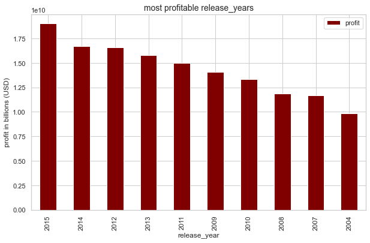

```python
#Plot a bar plot for release_year against profit
barplot (df, 'release_year', 'profit', 'maroon')
```

#### Observation

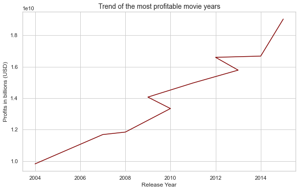

```python
#Plot a line graph to show the most pofitable years
profitable_years.plot(color= 'maroon', figsize = (10,6))
plt.xlabel('Release Year');
plt.ylabel('Profits in billions (USD)');
plt.title('Trend of the most profitable movie years', fontsize = 14);
```

### Research Question 2 (What is the relationship between the budgets and popularity of movies and profit?)

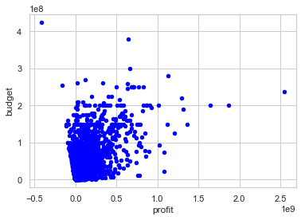

```python
#Plot a Scatter plot for budget and profit
df.plot(x="profit", y="budget", kind="scatter", color = 'blue');
```

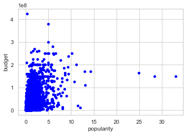

```python
#Scatter plot for popularity and profit
df.plot(x="popularity", y="budget", kind="scatter", color = 'blue');
```

#### Observation

> To better show the extent to which both columns affect the profit of movies, a line of best fit will be drawn and the correlation figure will also be calculated

```python
#A function for the line of best fit is defined

def best_fit(xcolumn, ycolumn):
    #Plotting a linear regression model fit
    lr = sns.regplot(x=df[xcolumn],y=df[ycolumn],color='gold')

    #describe/create the titles of the plot and style
    lr.set_xlabel(xcolumn)
    lr.set_ylabel(ycolumn  + ' in billions (USD)')
    lr.set_title(xcolumn +" against " + ycolumn,fontsize=14)
    sns.set(rc={'figure.figsize':(12, 8)})
    sns.set_style("whitegrid")

    correlation = df[xcolumn].corr(df[ycolumn])

    print("The correlation between " + xcolumn  + " and " + ycolumn + " is " + str(correlation))
```

##### a. Identify the relationship between budgets and profits

```
The correlation between budget and profit is 0.5268176539924018
```

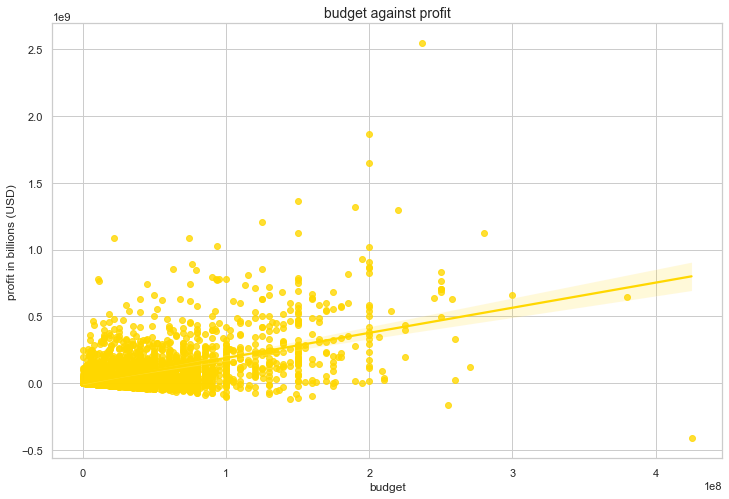

```python
best_fit('budget', 'profit')
```

#### Observation

> The diagram above shows that budgets and profits are moderately correlated. This implies that in a good number of cases, more resources invested into movies tend to earn more profit, although this cannot be said about all the movies from the dataset

##### b. Identify the relationshop between popularity and profits

```
The correlation between popularity and profit is 0.5962013674920571
```

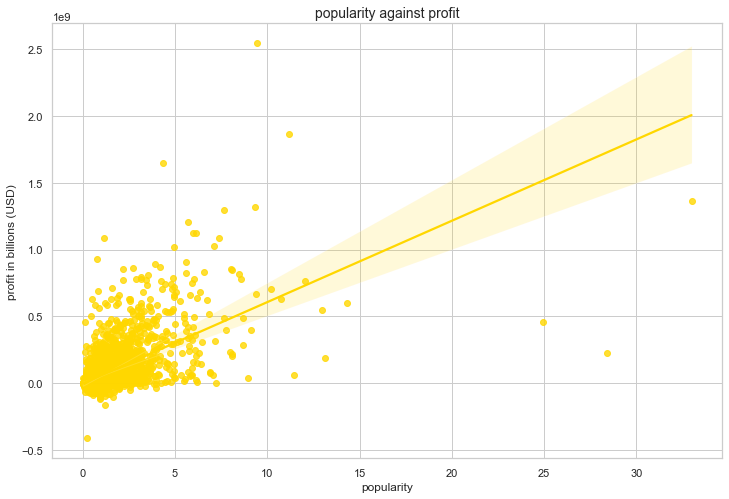

```python
best_fit('popularity', 'profit')
```

#### Observation

> The diagram above shows that popularity and profits are also moderately correlated. However, there is a stronger relationship between profits and popularity than between profits and budgets.

### Research Question 3 (What are the most profitable genres?)

##### a. Identify the most profitable genres

> The genres column has multiple values in them, separated by '|'

> To be able to properly analyse the values in there, we would have to split the value in this column

```python
#List the properties of the current dataset
df.info()
```

```
<class 'pandas.core.frame.DataFrame'>
Int64Index: 3854 entries, 0 to 10848
Data columns (total 12 columns):
 #   Column          Non-Null Count  Dtype
---  ------          --------------  -----
 0   id              3854 non-null   int64
 1   popularity      3854 non-null   float64
 2   budget          3854 non-null   int64
 3   revenue         3854 non-null   int32
 4   original_title  3854 non-null   object
 5   cast            3850 non-null   object
 6   director        3853 non-null   object
 7   runtime         3854 non-null   int64
 8   genres          3854 non-null   object
 9   release_date    3854 non-null   object
 10  release_year    3854 non-null   int64
 11  profit          3854 non-null   int64
dtypes: float64(1), int32(1), int64(5), object(5)
memory usage: 376.4+ KB
```

```python
#Fill
df=df.fillna(0)

df.info()
```

```
<class 'pandas.core.frame.DataFrame'>
Int64Index: 3854 entries, 0 to 10848
Data columns (total 12 columns):
 #   Column          Non-Null Count  Dtype
---  ------          --------------  -----
 0   id              3854 non-null   int64
 1   popularity      3854 non-null   float64
 2   budget          3854 non-null   int64
 3   revenue         3854 non-null   int32
 4   original_title  3854 non-null   object
 5   cast            3854 non-null   object
 6   director        3854 non-null   object
 7   runtime         3854 non-null   int64
 8   genres          3854 non-null   object
 9   release_date    3854 non-null   object
 10  release_year    3854 non-null   int64
 11  profit          3854 non-null   int64
dtypes: float64(1), int32(1), int64(5), object(5)
memory usage: 376.4+ KB
```

```python
#Select the specific columns (index, genres and profits) for the purpose of the analysis
cols = [0,6, 8,11]
df1 = df[df.columns[cols]]

#Using id and profit as index columns, the genres column is converted into a list
df2 = (df1.set_index(['id','director','profit'])
       .apply(lambda col: col.str.split('|')))

#Separate the list values in the genres column into different rows
df3 = df2.apply(pd.Series.explode).reset_index()

#Confirm the new dataframe
df3.head(10)
```

|  | id | director | profit | genres |
| --- | --- | --- | --- | --- |
| 0 | 135397 | Colin Trevorrow | 1363528810 | Action |
| 1 | 135397 | Colin Trevorrow | 1363528810 | Adventure |
| 2 | 135397 | Colin Trevorrow | 1363528810 | Science Fiction |
| 3 | 135397 | Colin Trevorrow | 1363528810 | Thriller |
| 4 | 76341 | George Miller | 228436354 | Action |
| 5 | 76341 | George Miller | 228436354 | Adventure |
| 6 | 76341 | George Miller | 228436354 | Science Fiction |
| 7 | 76341 | George Miller | 228436354 | Thriller |
| 8 | 262500 | Robert Schwentke | 185238201 | Adventure |
| 9 | 262500 | Robert Schwentke | 185238201 | Science Fiction |

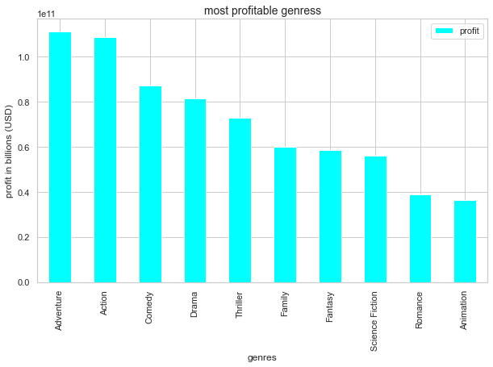

```python
#Plot a bar plot for genres against profit
barplot (df3, 'genres', 'profit', 'aqua')
```

#### Observation

> From the observation above, over the span of 55 years, adventure movies make the most profits, followed by action and comedy.

## Conclusions

> This analysis was performed on a data set containing information about over 10,000 movies collected from The Movie Database (TMDb) over a period of years from 1960 to 2015. The data set contains information about movies in tables such as the title, casts and director and it also contains information about the perfomance of movies in tables such as budget, revenue and popularity.

> As part of the data wrangling process, certain issues were idientified certain issues which were resolved in the data cleaning process. These issues included:
> 1. Dropping duplicated rows
> 2. Dropping movies with no budgets or revenues
> 3. Dropping irrelevant columns

## Sources

> The following are sources used for research during this project: https://pandas.pydata.org/docs/reference/api/pandas.DataFrame.nlargest.html

> https://www.geeksforgeeks.org/python-seaborn-regplot-method/#:~:text=regplot()%20%3A,for%20estimating%20the%20regression%20model.

> https://seaborn.pydata.org/generated/seaborn.regplot.html

> https://www.geeksforgeeks.org/python-pandas-dataframe-corr/#:~:text=corr()%20is%20used%20to,the%20dataframe%20it%20is%20ignored.

> https://stackoverflow.com/questions/42579908/use-corr-to-get-the-correlation-between-two-columns

> https://stackoverflow.com/questions/45487145/pandas-correlation-between-list-of-columns-x-whole-dataframe

> https://stackoverflow.com/questions/12680754/split-explode-pandas-dataframe-string-entry-to-separate-rows

> https://stackoverflow.com/questions/72470124/columns-must-have-matching-element-counts-pandas

> https://stackoverflow.com/questions/69534014/how-to-fix-columns-not-having-matching-element-counts-when-using-explode-in-pyth